# PISA data exploration

Filip Binkiewicz, Michał Kotlewski

January 27, 2017

# Stage one

## Basic outline of the data

We have: - Converted miliseconds to minutes (for readability) - Got rid of lazy and superhuman cases (outliers), i.e. all those records for which the solving time was over 45 minutes or below around 8 seconds

Below, we can see the final format of our data:

```r
head(onlyTimingsLong)
```

```
##            Kraj  Szkola Student Zestaw     Czas Zadanie Pozycja Obszar
## 10737 Australia 3600001 3601769     31   3.2592 R219Q01       3      R
## 10742 Australia 3600001 3605983     85 2.389233 R219Q01       2      R
## 10747 Australia 3600001 3602143     36 3.446917 R219Q01       4      R
## 10759 Australia 3600002 3611016     37 1.955867 R219Q01       1      R
## 10787 Australia 3600003 3605314     36 2.915917 R219Q01       4      R
## 10794 Australia 3600003 3611875     41 21.16292 R219Q01       2      R
```

## Distribution of solving time

On the following graph one can see the distribution of solving time for all records

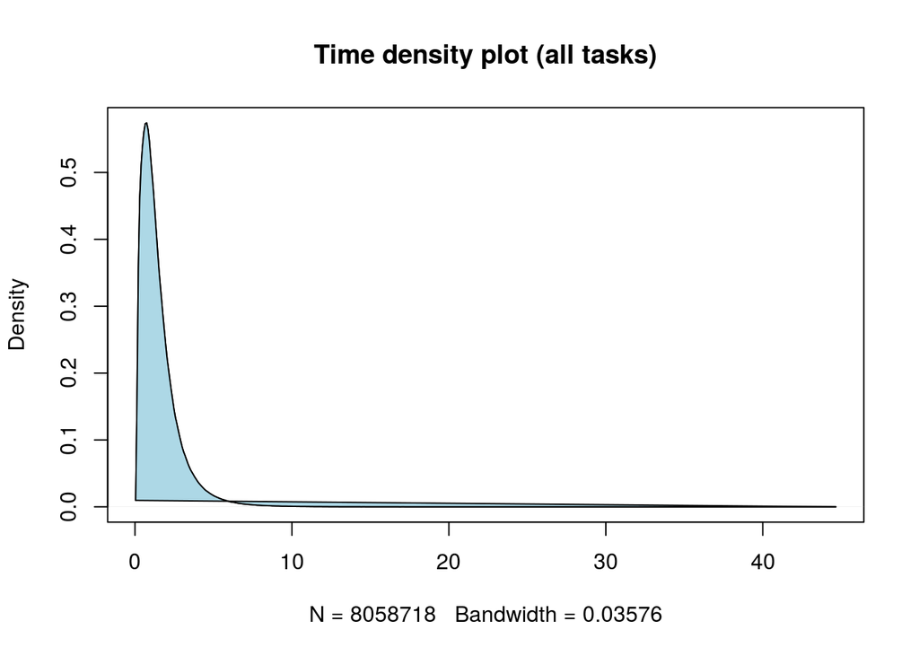

The purpose of this stage is to see the speed differences between countries and its dependence on factors such as the field of the task (math or reading) and the period of the exam the task was taken in. Below there are graphs to visualise this dependency. ## Average for each country

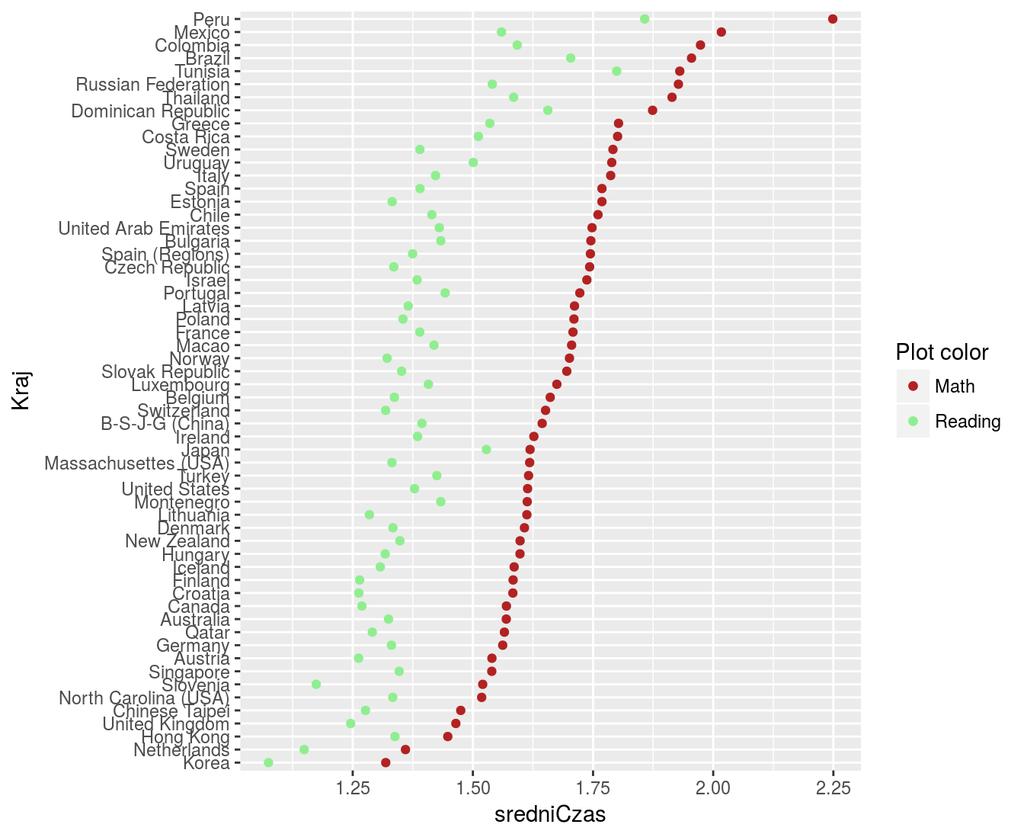

## Standard deviation by country

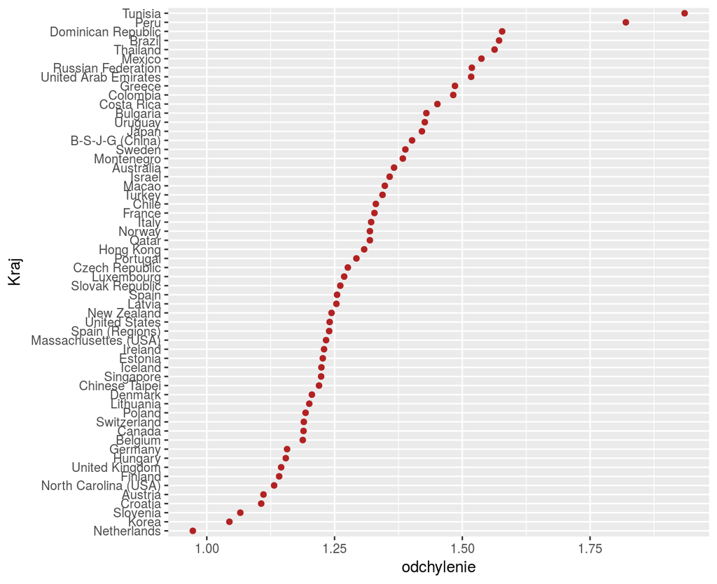

## Average for each set

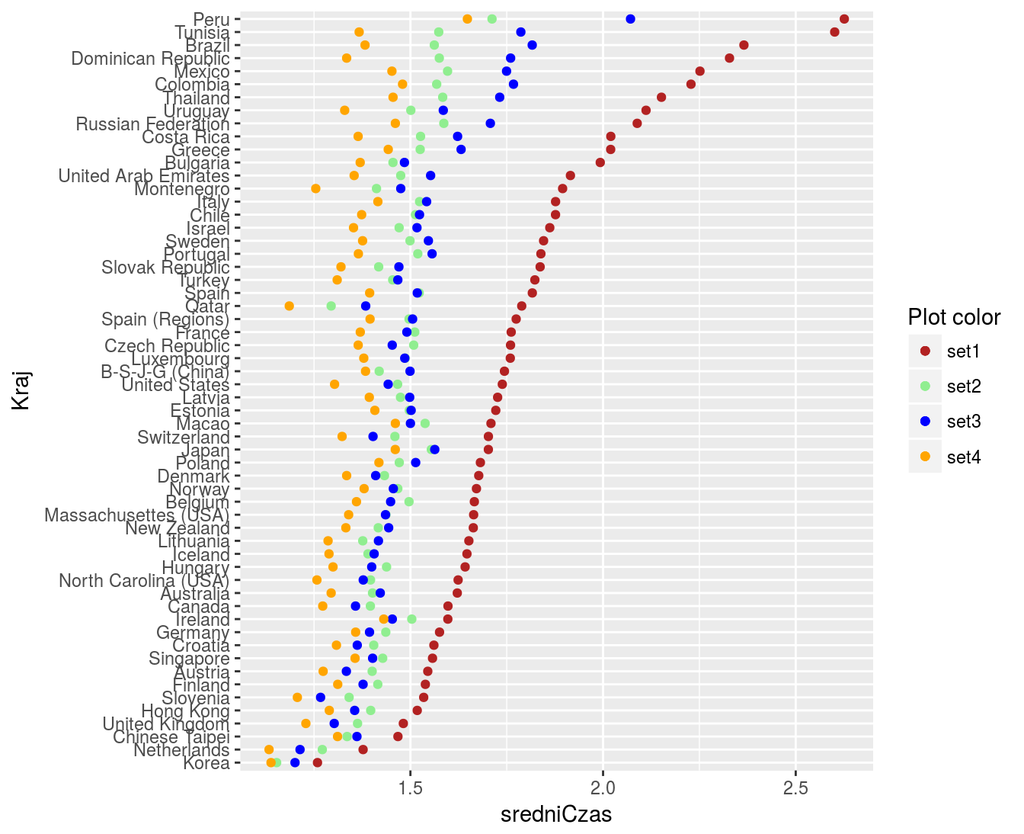

The obvious implications of the preceding graphs is that students tend to spend more time on the tasks in the earlier stages of the exam, as well as they often devote more attention (i.e. time) to the math-related problems rather than to the reading ones.

## Distribution by countries

The following graph shows the distribution of average time of solving one task in all the countries

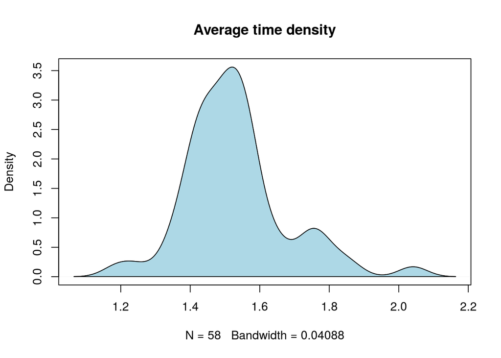

# Stage two

## Attempt to partition the data

To be able to properly operate on the data, we needed to take the following steps to shape-up the data:

- Group the records by schools
- For each school store the average time for each task
- Remove all tasks with more than 3000 NaNs
- Replace NaNs with column means
- Choose a smaller subset to ease the computations - 3000 schools

This is the final format of the data.

```r
head(tabelka[0:5])
```

```
##    Szkola   M00GQ01   M00KQ02   M033Q01  M034Q01
## 1 3600001 2.3100917 0.9637667 0.9872667 1.774696
## 2 3600002 0.9751167 1.4941250 0.7733250 1.184650
## 3 3600003 2.6070611 1.8883800 0.6273722 1.146072
## 4 3600004 1.3313500 1.4075750 0.8934889 1.950517
## 5 3600005 1.8396583 2.5239250 0.6859133 1.625180
## 6 3600006 2.4676667 1.5530333 0.8542167 1.532758
```

```r
smallData <- tabelka[sample(1:nrow(tabelka), 3000), ]
```

To group the schools (and further, diagnose the test-taking schemes), we have used the K-means method. Below, there are two 2-dimensional representations of the groups. The first one uses a projection of our design: the two axes are mean time of solving math tasks and mean time of solving reading tasks. The other one is a projection with classical scaling.

## K-means - math / reading representation

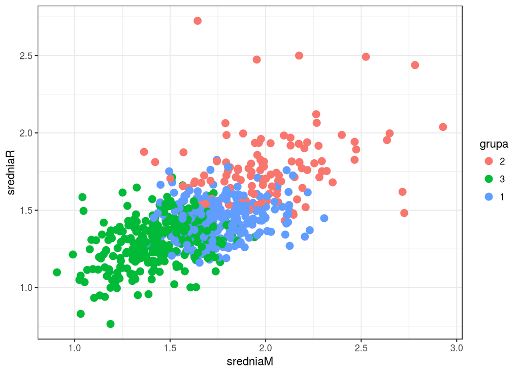

## K-means with classical scaling

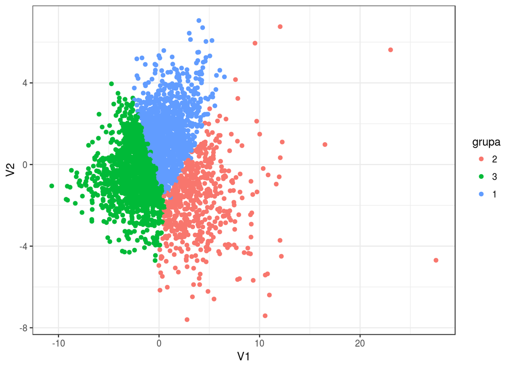

## Why three groups?

It’s necessary to explain why there are three groups chosen. One can see it on the following histogram, which shows the $ W(C) $ measure, which sum the distances between nodes in each group, for the K-means partitioning for 2 through 7 groups.

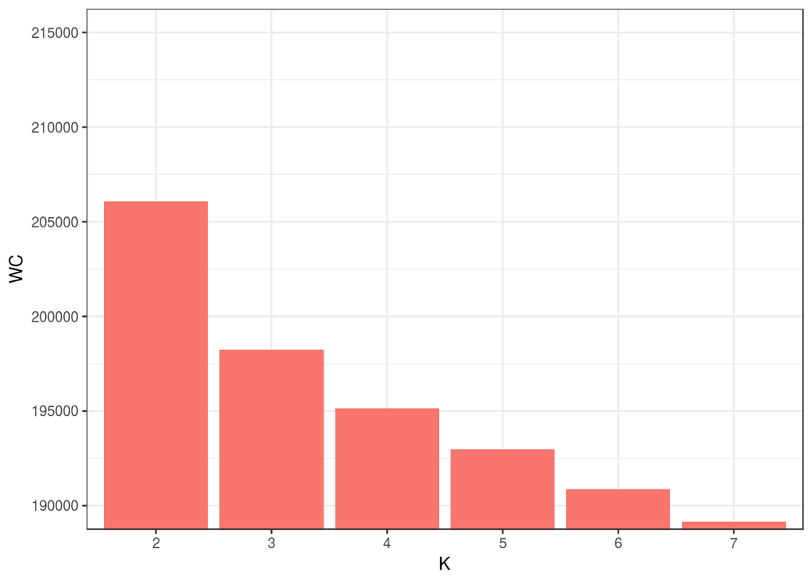

The choice seems justified now, as the leap between 3 and 4 groups doesn’t seem to be tall enough to be considered.

## Names for the groups

- Group 1: the average
- Group 2: the patient
- Group 3: the fast and furious

# Stage three

## Groups and countries

Below, one can see the density of each group in every country

## Groups in all countries

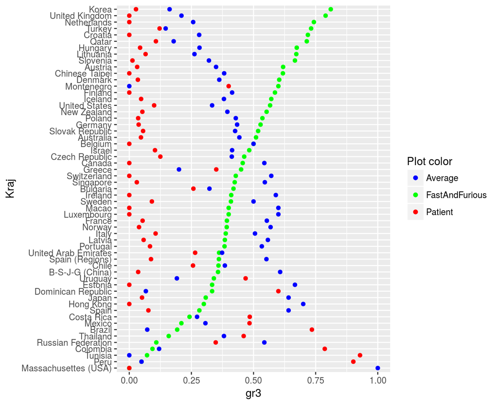

We have selected four countries, which happened to be in similar distances between each other on the average time graph in stage one - Korea, USA, Poland and Peru, and plotted the densities for each group on the following pie charts.

## Groups in selected countries

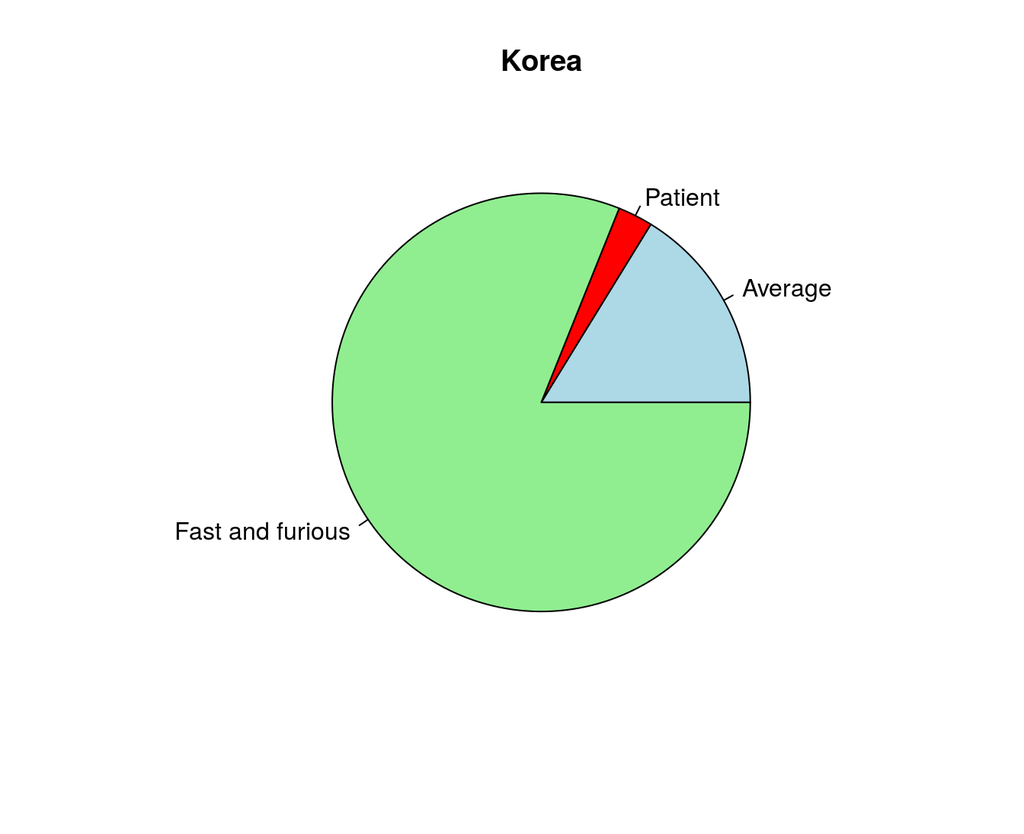

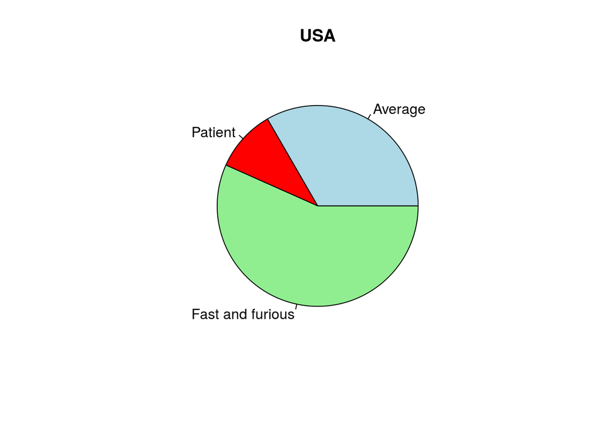

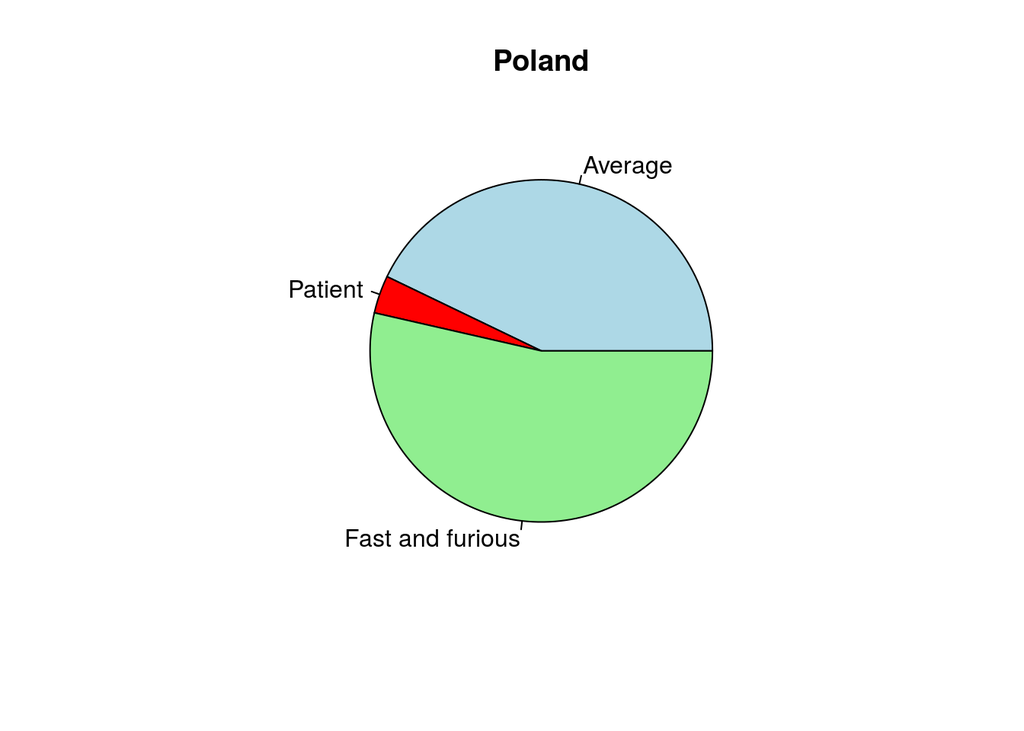

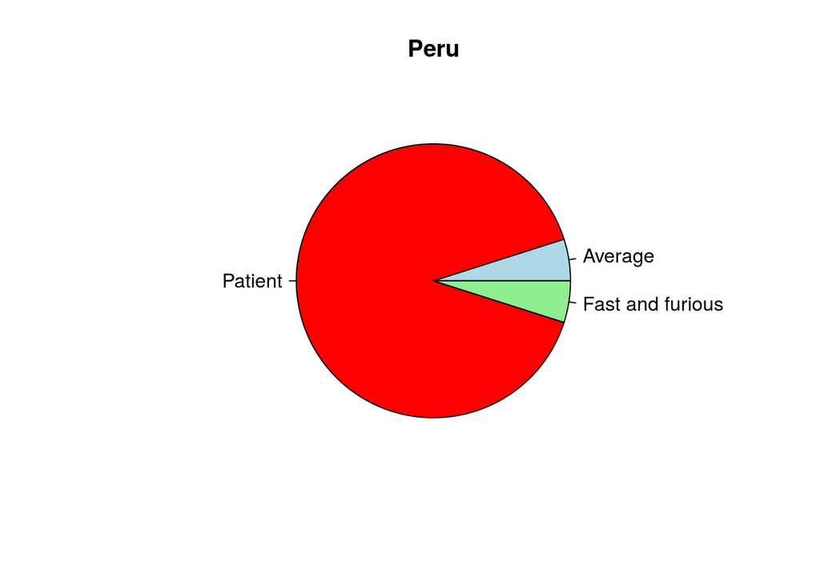

## Is this related to the general outcome in the country?

The most important question of this stage is whether the partitioning that we have established is in any way related to the general outcome in each country. The pie chart suggest yes, but they don’t show the whole variety of countries. So the next three plots should clear things up

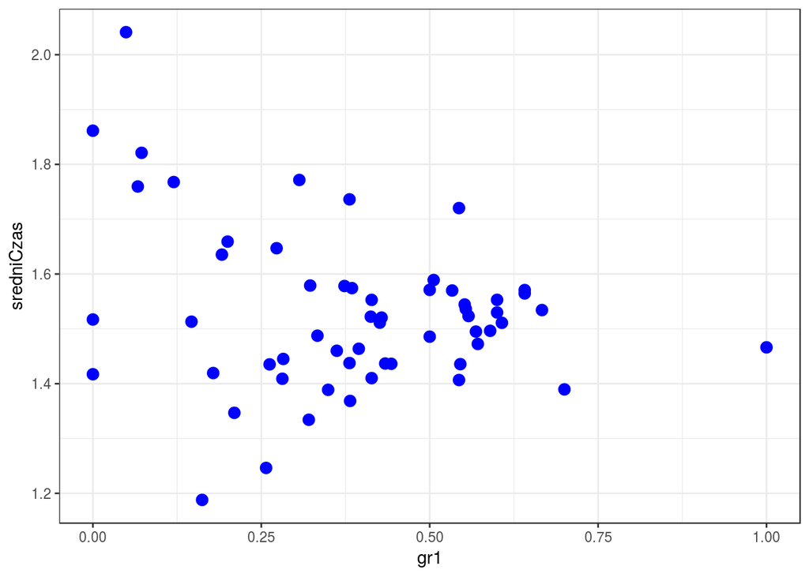

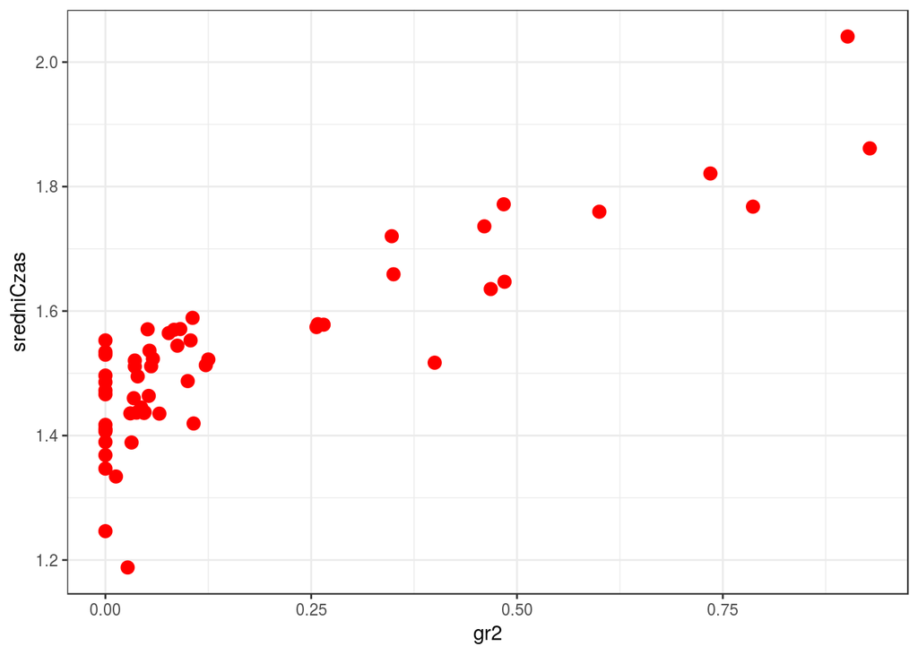

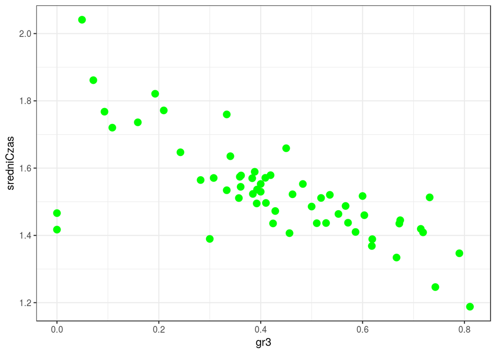

It seems that the average group doesn’t affect the outcome too much, but the relation between each country’s percentage of the fast and furious and the average time is undeniable. The same goes for the patient group